# Report

## Results:

The ultimate question addressed in this report is does the eyespot ‘sparkle’ decrease the predation rate of lepidoptera. For each experiment, I used a binomial logit-link generalized linear model, with quasi-likelihoods to account for overdispersion, to analyse the effect of design, time (collection), temperature, and location (excluding experiment 3) on the likelihood of predation. An interaction term between location and collection was included in the model for experiment 1. All analyses and data cleaning were carried out in R (ver 4.3.3) with the tidyverse range of packages (Wickham et al, 2019), car (Fox et al, 2023), patchwork (Lin et al, 2024) and ggeffects (Lüdecke et al, 2024) packages. Model residuals were checked with the performance package (Lüdecke et al, 2021). Summary tables were produced with broom (Robinson et al 2022) and KableExtra (Zhu, 2020) packages. In the analysis, the term collection refers to the event of collecting in the models to count predation levels. This happened 9 times throughout each experiment. Collection is used as a reference for time into the experiment in analyses and is used as a numerical variable, so that any potential effects of learning can be investigated.

## Experiment 1:

# Influence of Design on Predation:

The main hypothesis of this experiment was that design 3 (2 eyespots) would show the least amount of predation compared to designs 1 (blank) and 2 (1 eyespot), with blank models showing the greatest likelihood of predation.

Linear model coefficients

| Predictors | Estimates | Z-value | P | Lower 95% CI | Upper 95% CI |
| --- | --- | --- | --- | --- | --- |
| (Intercept) | 3.52 | 5.39 | 0.00 | 2.26 | 4.82 |
| day_of_the_exp | 0.00 | 0.03 | 0.98 | -0.06 | 0.06 |
| location2 | -1.76 | -5.12 | 0.00 | -2.44 | -1.09 |
| design2 | -1.16 | -6.43 | 0.00 | -1.52 | -0.81 |
| design3 | -1.34 | -7.41 | 0.00 | -1.69 | -0.99 |
| temperature | -0.21 | -3.85 | 0.00 | -0.32 | -0.10 |
| day_of_the_exp:location2 | 0.48 | 6.86 | 0.00 | 0.35 | 0.62 |

**Table 1** Eyespot models show significantly lower log odds likelihood of predation compared to blank models. Output displaying estimated coefficients with 95% confidence intervals, z-values, and associated p-values from a binomial logit-link generalized linear model assessing the predictors of predation. The predictors include collection, location (2 levels), design (3 levels), temperature and an interaction between collection and location.

There was a significant overall effect of design on likelihood of predation (χ² 2,1050 = 67.96, P = <0.0001), with blank models showing a mean predation probability of 84.23% [95% CI: 80.04 - 87.68%]. Mean probability of predation for models with 1 eyespot was 62.57% [56.95-67.87%], and the lowest mean probability of predation was 58.43% [52.75-63.89%] for models with 2 eyespots.

Mean Probability of Predation For Each Design

| Design | Probability | SE | Lower 95% CI | Upper 95% CI |
| --- | --- | --- | --- | --- |
| 1 | 0.842 | 0.019 | 0.801 | 0.877 |
| 2 | 0.626 | 0.028 | 0.570 | 0.678 |
| 3 | 0.584 | 0.028 | 0.528 | 0.639 |

**Table 2** Blank models predated significantly more than eyespot models. Design 1 (blank), design 2 (1 eyespot), design 3 (2 eyespots). Table shows mean probabilities of predation across three designs of artificial Lepidoptera left exposed for 48 hours. Values obtained using emmeans function, which analysed a binomial logit-link generalized linear model (Table 1). The SE column represents standard error, and lower and upper 95% confidence intervals are shown.

Post hoc analysis showed that these differences were statistically significant for blank models compared to 1 eyespot models (Tukey test:zInf = 6.43, P = <0.0001) and 2 eyespot models (zInf = 7.41, P = <0.0001). The analysis showed that the odds of predation for blank models was 3.2 times higher than 1 eyespot models (SE = 0.58, z = 6.43, p <0.0001) and 3.8 times higher than 2 eyespot models (SE = 0.69, z = 7.41, p <0.0001). There was no overall evidence of a difference between 1 eyespot models and 2 eyespot models (SE = 0.19, z = 1.08, p = 0.529).

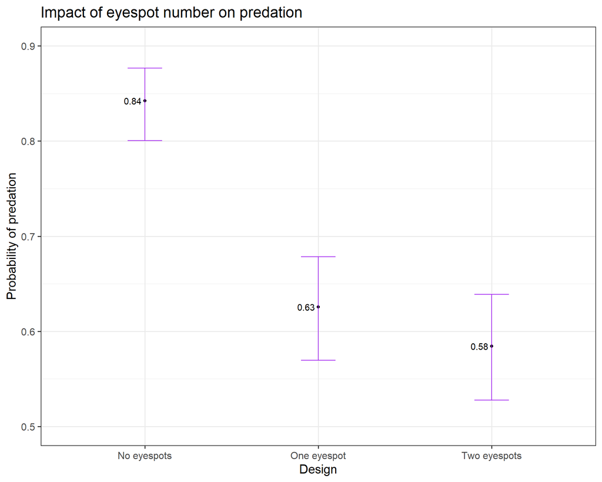

**Figure 1:** Probability of predation higher for blank design. Plot shows mean probabilities of predation across three designs of artificial Lepidoptera left exposed for 48 hours. Design 1 (blank), design 2(1 eyespot) and design 3 (2 eyespots). Y axis represents predicted probabilities of predation, calculated using the emmeans function which analysed a binomial logit-link generalized linear model (Table 1). Solid points represent mean probabilities. Horizontal lines and labels represent upper and lower 95% confidence intervals. X axis represents the three designs.

## Influence of Learning on Predation:

It was hypothesised that the level of predation would increase over the experimental period (including all experiments). To measure this, ‘collection’ was used as a reference for time into the experiment. It was plausible that the effects of learning could be different between the two locations therefore an interaction term between collection and location was included. There was significant evidence of an interaction between collection and location (χ² 1,1050 = 54.81, P = <0.001). I found a significant positive relationship between collection and probability of predation at location 2 (logit-odds = 0.48 [95% CI: 0.35 - 0.62], z = 6.86, d.f = 1050, P = <0.0001). In contrast, at location 1, the effect of collection on predation was not statistically significant. This suggests that learning occurred in birds at location 2 but not location 1. It is worth noting that there was an increase in probability of predation after collection 2 at location 1.

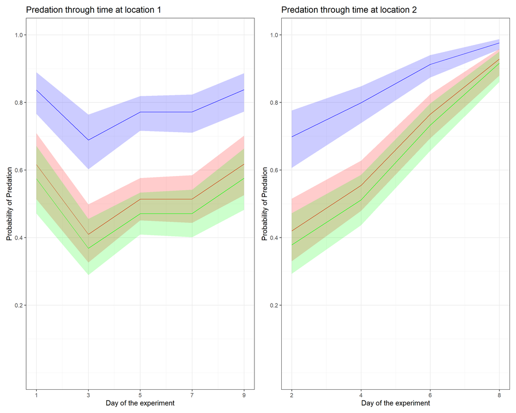

**Figure 2:** The impact of learning on predation. The plot shows the relationship between probability of predation and time into the experiment at each location (left = location 1, right = location 2). Y axis represents probability of predation and x axis represents collection event number. Blue represents design 1 (blank), red represents design 2 (1 eyespot) and green represents design 3 (2 eyespots). Artificial Lepidopteran models were exposed to predators in 48 hour periods across 9 collection events. The shaded zones represent the 95% confidence intervals of predictions for each design. Predictions were made using the augment_glm function which analysed a binomial logit-link generalized linear model.

## Influence of location on Predation

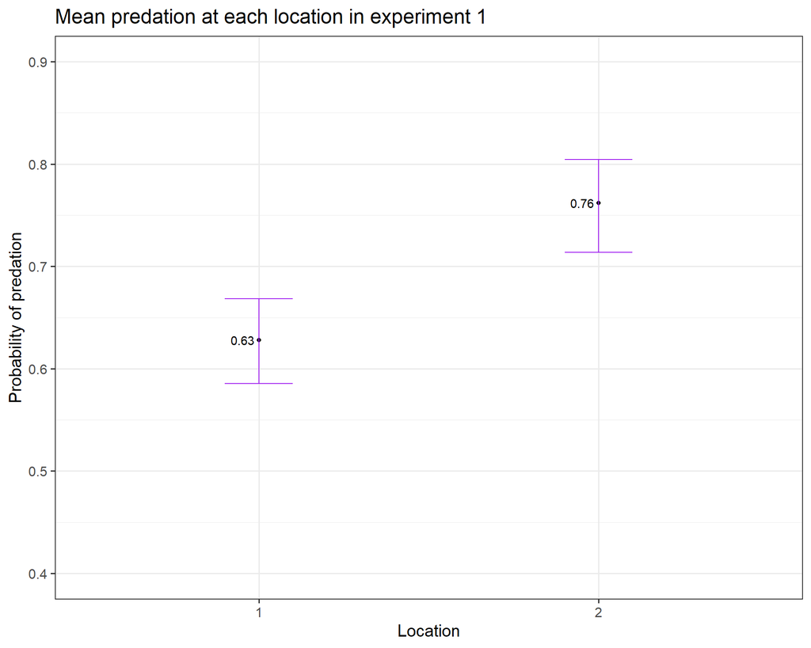

## Influence of Temperature on Predation:

Model analysis showed a significant negative relationship between temperature and probability of predation (logit-odds = -0.21 [95% CI: -0.32 - -0.10], z = -3.85, df = 1050, P = <0.0001).

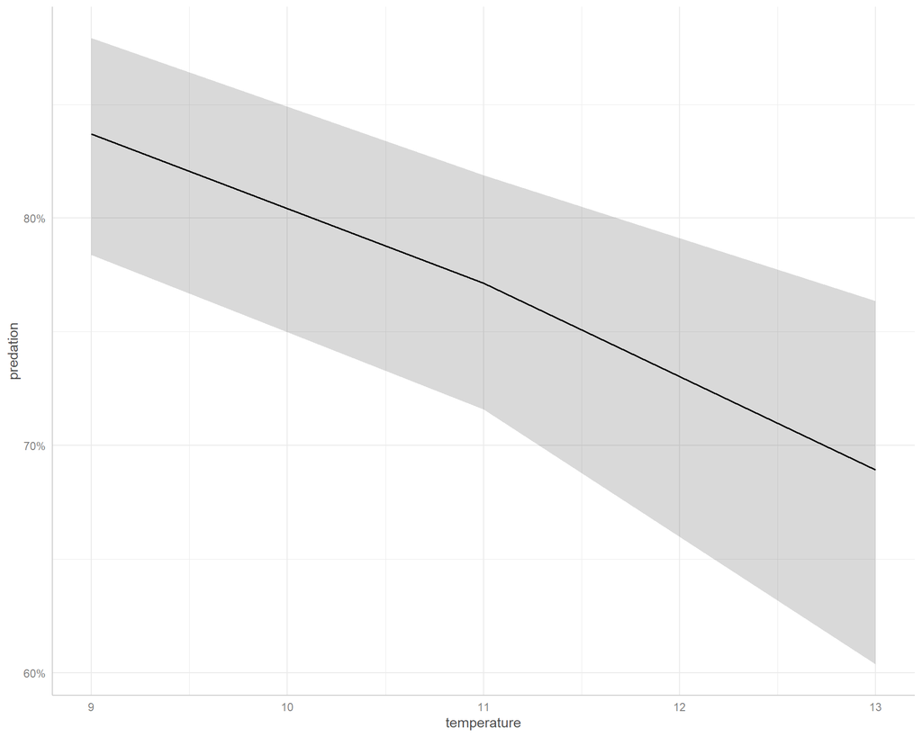

**Figure 4** Probability of predation decreases with increases in temperature for experiment 1. Probability of predation decreases from 84% (95% CI: 78 - 88%) at 9 degrees celsius to 69% (95% CI: 60 - 76%) at 13 degrees celsius. Black line shows this decrease and grey area represents 95% confidence intervals of predictions. Y axis represents the predicted probabilities of predation, obtained using the ggpredict function, which analysed a binomial logit-link generalized linear model (Table 1).

# Experiment 2:

## Influence of Design on Predation:

The main hypothesis for this experiment was that design 1 (‘sparkle’ within eyespots) would show the lowest likelihood of predation, and that design 3 (control - 2 eyespots, no ‘sparkle’) would show the highest likelihood of predation compared to design 1 and design 2 (‘sparkle’ outside of eyespots). It was hypothesised that models with ‘sparkles’ outside of the eyespots would show lower predation rate compared to the control.

Linear model coefficients

| Predictors | Estimates | Z-value | P | Lower 95% CI | Upper 95% CI |
| --- | --- | --- | --- | --- | --- |
| (Intercept) | -1.55 | -7.87 | 0.00 | -1.94 | -1.17 |
| design2 | 0.27 | 1.56 | 0.12 | -0.07 | 0.60 |
| design3 | 0.25 | 1.48 | 0.14 | -0.08 | 0.58 |
| day_of_the_exp | 0.27 | 9.62 | 0.00 | 0.22 | 0.33 |
| location2 | 1.04 | 7.32 | 0.00 | 0.76 | 1.32 |

Design did not have a significant effect on the likelihood of predation (χ² 2,1033 = 3.1, P = 0.2). Models with eyespots containing a ‘sparkle’ showed a predicted mean predation probability of 57.91% [95% CI: 52.11 - 63.50%]. There was a 64.23% [58.55 - 69.53%] probability for models with ‘sparkles’ outside of eyespots and a 63.87% [58.21 - 69.16%] probability for control models.

Mean Probability of Predation For Each Design

| Design | Probability | SE | Lower 95% CI | Upper 95% CI |
| --- | --- | --- | --- | --- |
| 1 | 0.579 | 0.029 | 0.521 | 0.635 |
| 2 | 0.642 | 0.028 | 0.586 | 0.695 |
| 3 | 0.639 | 0.028 | 0.582 | 0.692 |

**Table 4:** Models with ‘sparkles’ within eyespots show slightly lower probability of predation, but this difference is not significant. Design 1 (‘sparkle’ within eyespots), design 2 (‘sparkle’ outside of eyespots), design 3 (control). Table shows mean probabilities of predation across three designs of artificial Lepidoptera left exposed for 24 hours. Values obtained using emmeans function, which analysed a binomial logit-link generalized linear model (Table 3). The SE column represents standard error, and lower and upper 95% confidence intervals are shown.

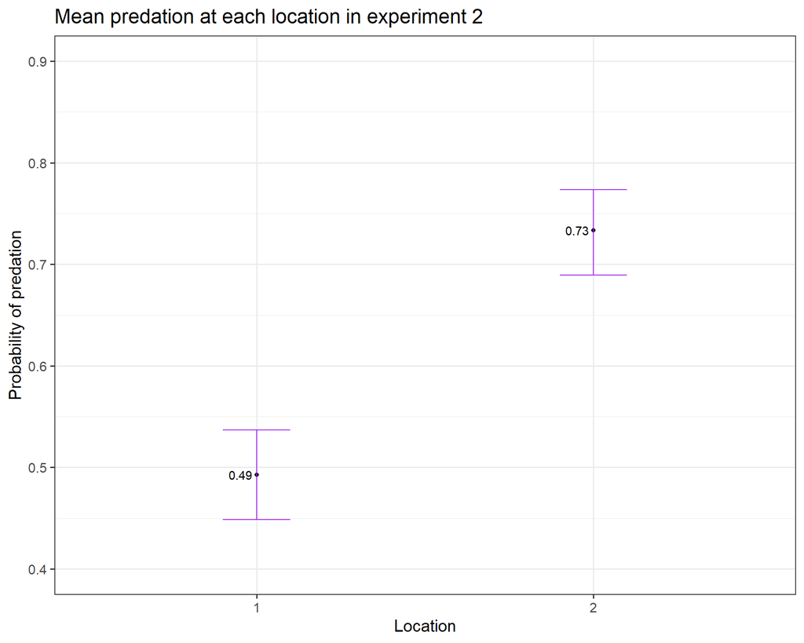

Adding the interaction term enabled pairwise comparisons between design to be made within each location. As expected, post hoc analysis did not show a significant difference in the odds of predation between designs at location 2. In location 1, comparisons between designs did indicate that predation was approximately 0.65 times less likely to occur in models with eyespots containing ‘sparkles’. However, these differences were not large enough to be significant (design 1 - design 2: SE = 0.15, z = -1.87, P = 0.15)(design 1 - design 3: SE = 0.14, z = -1.99, P = 0.11). This is supported by the interaction between location and design not having a significant effect on predation (χ² 2,1033 = 2.01, P = 0.37). Predicted probabilities calculated from the final model, with the interaction term removed (Table 3), are shown in figure 6.

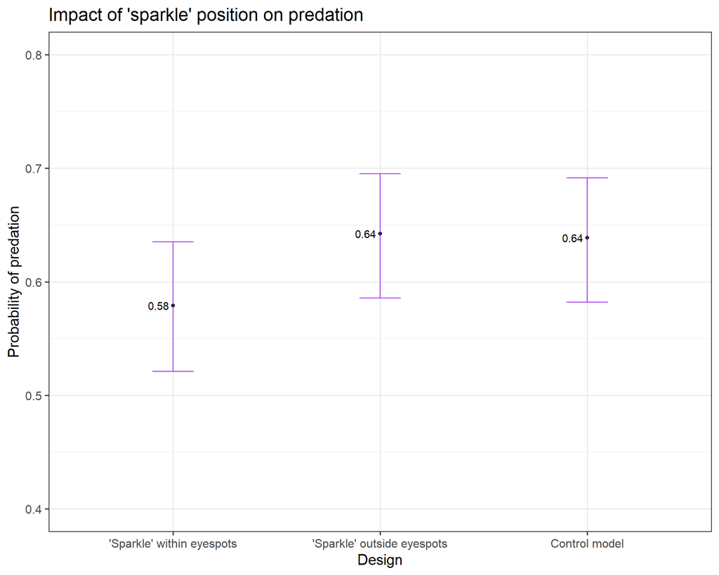

**Figure 6:** Models with ‘sparkles’ within eyespots show slightly lower probability of predation, but this difference is not significant. Design 1 (‘sparkle’ within eyespots), design 2 (‘sparkle’ outside of eyespots), design 3 (control). Plot shows mean probabilities of predation across three designs of artificial Lepidoptera left exposed for 24 hours. Values obtained using emmeans function, which analysed a binomial logit-link generalized linear model (Table 3). Y axis represents predicted probabilities of predation with solid points representing mean probabilities. Horizontal lines and labels represent upper and lower 95% confidence intervals. X axis represent the three designs.

## Influence of Learning on Predation:

There was no significant evidence of an interaction between collection and location (χ² 1,1033 = 0.03, P = 0.86). This indicated that the effect of collection on the likelihood of predation did not differ between locations. Model analysis showed a significant positive relationship between collection and probability of predation (logit-odds = 0.27 [95% CI: 0.22 - 0.33], z = 9.62, df = 1033, P = <0.0001), indicating that the probability of predation increased throughout the experiment, most likely due to learning.

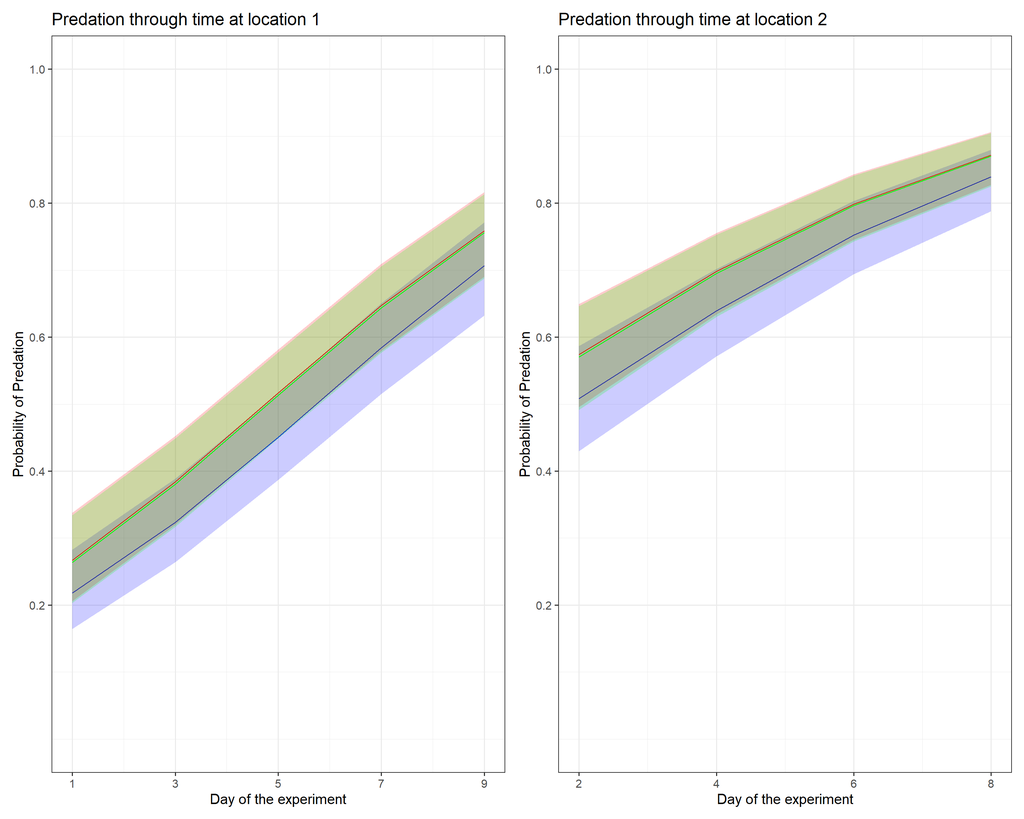

**Figure 7:** The impact of learning on predation shows the same pattern across designs and locations. The plot shows the relationship between probability of predation and time into the experiment at each location (left = location 1, right = location 2). Y axis represents probability of predation and x axis represents collection event number. Blue represents design 1 (‘sparkle’ within eyespots), red represents design 2 (‘sparkle’ outside of eyespots) and green represents design 3 (control). Artificial Lepidopteran models were exposed to predators in 24 hour periods across 9 collection events. The shaded zones represent the 95% confidence intervals of predictions for each design. Predictions were made using the augment_glm function which analysed a binomial logit-link generalized linear model(Table 3).

## Influence of Location on Predation:

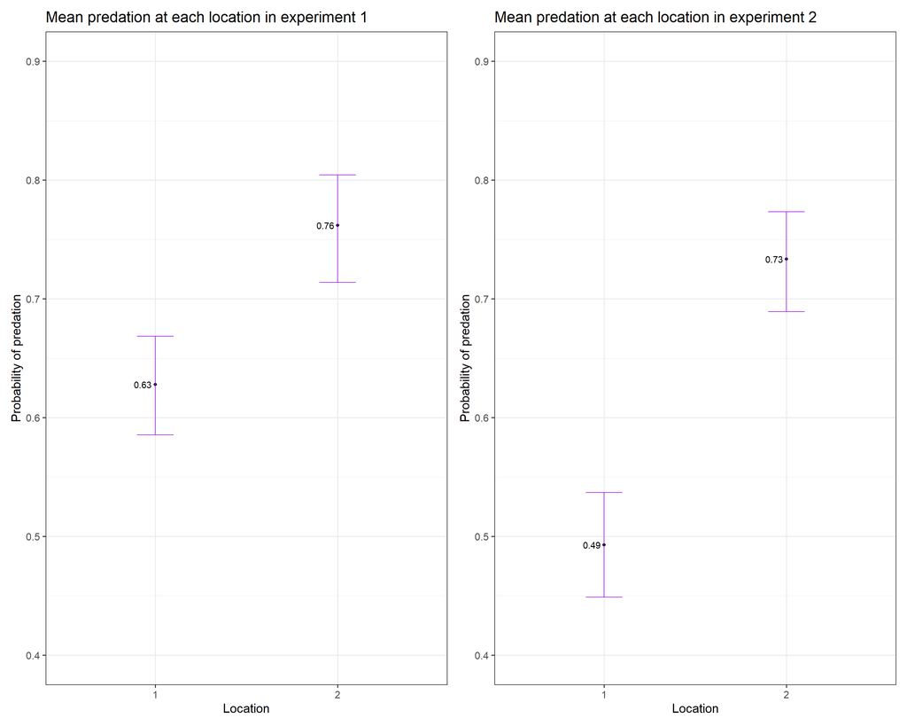

## Influence of Temperature on Predation:

There was no significant overall effect of temperature on predation in experiment 2 (χ² 1,1033 = 2.79, P = 0.09), and this was removed as a predictor from the final model (Table 3)

# Experiment 3:

## Influence of Design on Predation:

The main hypothesis of this experiment was that design 3 (control - 2 eyespots without a ‘sparkle’) would show the highest likelihood of predation compared to the two ‘sparkle’ designs. It was hypothesised that design 1 (UV-reflective ‘sparkle’) would show a lower likelihood of predation compared to design 2 (UV-absorbant ‘sparkle’).

Linear model coefficients

| Predictors | Estimates | Z-value | P | Lower 95% CI | Upper 95% CI |
| --- | --- | --- | --- | --- | --- |
| (Intercept) | -0.86 | -5.16 | 0.00 | -1.19 | -0.54 |
| design2 | -0.14 | -0.90 | 0.37 | -0.45 | 0.17 |
| design3 | 0.37 | 2.36 | 0.02 | 0.06 | 0.68 |
| day_of_the_exp | 0.19 | 7.65 | 0.00 | 0.15 | 0.25 |

Mean Probability of Predation For Each Design

| Design | Probability | SE | Lower 95% CI | Upper 95% CI |
| --- | --- | --- | --- | --- |
| 1 | 0.527 | 0.028 | 0.473 | 0.581 |
| 2 | 0.492 | 0.028 | 0.438 | 0.546 |
| 3 | 0.618 | 0.027 | 0.565 | 0.669 |

**Table 6** ‘Sparkle’ models predated significantly less than control models, but no significant difference between UV-reflective and UV-absorbant models. Design 1 (UV-reflective), design 2 (UV-absorbant), design 3 (2 eyespots - control). Table shows probabilities of predation across three designs of artificial Lepidoptera left exposed for 8 hours. Values obtained using emmeans function, which analysed a binomial logit-link generalized linear model (Table 5). The SE column represents standard error, and lower and upper 95% confidence intervals are shown.

Post hoc analysis showed that these differences were statistically significant for control models compared to UV-reflective models (Tukey test:zInf = -2.36, P = <0.05) and UV-absorbant models (zInf = -3.25, P = <0.01). The analysis showed that the odds of predation for UV-reflective models was 0.69 times lower than control models (SE = 0.11, z = -2.36, p <0.05) and the odds of predation for UV-absorbant models was 0.60 times lower than control models (SE = 0.09 z = -3.25, p <0.01). There was no overall evidence of a difference between both ‘sparkle’ models (SE = 0.18, z = 0.90, p = 0.64).

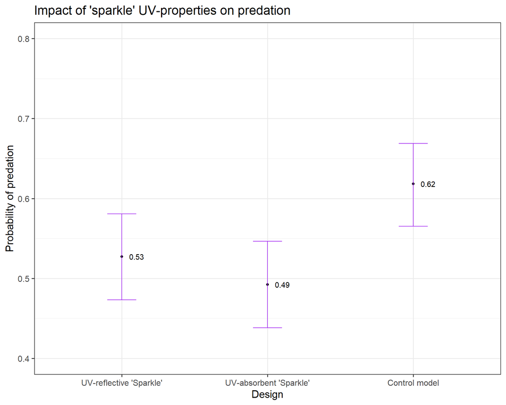

**Figure 9** ‘Sparkle’ models predated significantly less than control models, but no significant difference between UV-reflective and UV-absorbant models. Design 1 (UV-reflective), design 2 (UV-absorbant), design 3 (2 eyespots - control). Plot shows probabilities of predation across three designs of artificial Lepidoptera left exposed for 8 hours. Y axis represents predicted probabilities of predation, calculated using the emmeans function which analysed a binomial logit-link generalized linear model (Table 5). Solid points represent mean probabilities. Horizontal lines and labels represent upper and lower 95% confidence intervals. X axis represent the three designs.

## Influence of Learning on Predation:

Model analysis showed a significant positive relationship between collection and probability of predation (logit-odds = 0.20 [95% CI: 0.15 - 0.25], z = 7.65, df = 1051, P = <0.0001), indicating that the probability of predation increased throughout the experiment, most likely due to learning.

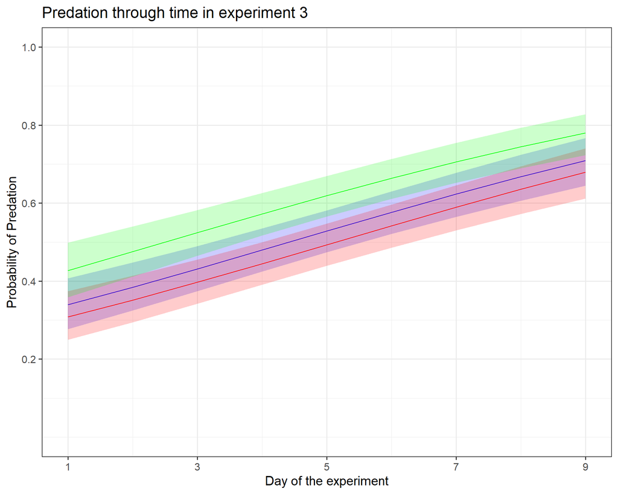